# GOT1 knockdown vs control in pancreatic cancer — GSE157830

GEO RNA-seq Portfolio · differential expression re-analysis

Author

jam-sudo

Published

June 12, 2026

## Biological question

**GOT1** (glutamic-oxaloacetic transaminase 1) is a cytosolic aspartate aminotransferase that pancreatic ductal adenocarcinoma (PDAC) cells rely on to maintain redox balance. This dataset (Kremer *et al.*, *“Labile Iron Release Primes Pancreatic Cancer for Ferroptosis”*) uses a **doxycycline-inducible shRNA** to knock down GOT1 in two PDAC cell lines and profiles the transcriptome by RNA-seq.

> **Question:** Which genes and pathways change when GOT1 is knocked down in PDAC cells, consistently across two cell lines? We compare **GOT1 knockdown (+Dox) vs control (−Dox)** while statistically accounting for the cell-line baseline.
- **Accession:** GSE157830 · *Homo sapiens* · Illumina NovaSeq 6000 (GPL24676)
- **Design:** 2 cell lines (Tu8902, MiaPaCa2) × 2 treatments (control, GOT1 knockdown) × 3 replicates = 12 samples.
- A full pre-analysis suitability report is in `SUITABILITY.md`.

## 1. Provenance: save verbatim GEO metadata

The cleaned metadata used for modelling is derived (and documented) in the suitability note. Here we additionally pull the **verbatim** GEO sample metadata for provenance. Network-dependent; wrapped so a failure does not break the report.

```r
meta_raw_path <- file.path(DATA_DIR, paste0(ACC, "_sample_metadata.csv"))
if (!file.exists(meta_raw_path)) {
  try({
    geo <- fetch_geo(ACC, dest_dir = DATA_DIR, get_supp = FALSE)
  }, silent = TRUE)
}
if (file.exists(meta_raw_path)) {
  cat("Verbatim GEO metadata saved at:", meta_raw_path, "\n")
} else {
  cat("GEO metadata fetch skipped/unavailable; cleaned metadata is used below.\n")
}
```

```
Verbatim GEO metadata saved at: /Users/jam/GEO/projects/GSE157830/data/GSE157830_sample_metadata.csv
```

## 2. Load gene-level RSEM counts (rounded to integers)

The supplementary file `GSE157830_genes.counts.txt.gz` holds **RSEM expected counts** with 8 annotation columns + 12 sample columns. RSEM counts are fractional, so they are **rounded** before DESeq2 (the FPKM/TPM files are *not* used). `ensembl_gene_id` is the unique row key; `gene_name` is kept as a label.

```r
raw <- data.table::fread(COUNTS_GZ)

anno_cols <- c("gene_name", "ensembl_gene_id", "gene_type", "entrez",
               "transcript_name", "ensembl_transcript", "transcript_type",
               "gene_description")
sample_cols <- setdiff(names(raw), anno_cols)
stopifnot(length(sample_cols) == 12)

gene_anno <- raw[, .(ensembl_gene_id, gene_name, entrez, gene_type)]
gene_anno[, gene_id := make.unique(as.character(ensembl_gene_id))]

counts <- as.matrix(raw[, ..sample_cols])
rownames(counts) <- gene_anno$gene_id
counts <- round(counts)                       # RSEM expected counts -> integers
storage.mode(counts) <- "integer"

cat("Count matrix:", nrow(counts), "genes x", ncol(counts), "samples\n")
```

```
Count matrix: 58721 genes x 12 samples
```

```r
cat("Fractional values were rounded (RSEM expected counts).\n")
```

```
Fractional values were rounded (RSEM expected counts).
```

## 3. Cleaned metadata & experimental design

Groups come from the GEO `genotype/variation` characteristics field, not the free-text title (see suitability note, assumption A1). Reference levels: `treatment = control`, `cell_line = Tu8902`.

```r
meta <- read.csv(CLEAN_META, stringsAsFactors = FALSE)
rownames(meta) <- meta$sample_name
meta <- meta[sample_cols, ]                    # align to count columns
meta$cell_line <- factor(meta$cell_line, levels = c("Tu8902", "MiaPaCa2"))
meta$treatment <- factor(meta$treatment, levels = c("control", "GOT1_knockdown"))
meta$group     <- paste(meta$cell_line, meta$treatment, sep = " / ")

stopifnot(identical(colnames(counts), rownames(meta)))
write_results_table(meta, file.path(TAB_DIR, paste0(ACC, "_metadata_clean.csv")))
knitr::kable(meta[, c("geo_accession", "cell_line", "treatment", "dox", "replicate")],
             caption = "Cleaned sample metadata (design table)")
```

Cleaned sample metadata (design table)

|  | geo_accession | cell_line | treatment | dox | replicate |
| --- | --- | --- | --- | --- | --- |
| Tu8902_shGOT1_mnsdox_1 | GSM4775595 | Tu8902 | control | minus | 1 |
| Tu8902_shGOT1_mnsdox_2 | GSM4775596 | Tu8902 | control | minus | 2 |
| Tu8902_shGOT1_mnsdox_3 | GSM4775597 | Tu8902 | control | minus | 3 |
| Tu8902_shGOT1_plsdox_1 | GSM4775598 | Tu8902 | GOT1_knockdown | plus | 1 |
| Tu8902_shGOT1_plsdox_2 | GSM4775599 | Tu8902 | GOT1_knockdown | plus | 2 |
| Tu8902_shGOT1_plsdox_3 | GSM4775600 | Tu8902 | GOT1_knockdown | plus | 3 |
| Mia_shGOT1_mnsdox_1 | GSM4775601 | MiaPaCa2 | control | minus | 1 |
| Mia_shGOT1_mnsdox_2 | GSM4775602 | MiaPaCa2 | control | minus | 2 |
| Mia_shGOT1_mnsdox_3 | GSM4775603 | MiaPaCa2 | control | minus | 3 |
| Mia_shGOT1_plsdox_1 | GSM4775604 | MiaPaCa2 | GOT1_knockdown | plus | 1 |
| Mia_shGOT1_plsdox_2 | GSM4775605 | MiaPaCa2 | GOT1_knockdown | plus | 2 |
| Mia_shGOT1_plsdox_3 | GSM4775606 | MiaPaCa2 | GOT1_knockdown | plus | 3 |

**Design formula:** `~ cell_line + treatment` — adjusts for the cell-line baseline and estimates the shared GOT1-knockdown effect. **Primary contrast:** `treatment` GOT1_knockdown vs control.

## 4. Differential expression (DESeq2)

```r
de <- run_deseq2(
  counts   = counts,
  coldata  = meta,
  design   = ~ cell_line + treatment,
  contrast = c("treatment", "GOT1_knockdown", "control")
)
# Shrunken LFCs for ranking/plots (apeglm).
res_shrink <- lfcShrink(de$dds, coef = "treatment_GOT1_knockdown_vs_control",
                        type = "apeglm")
```

[output not shown]

```r
de$res_df$log2FoldChange_shrunk <- res_shrink[de$res_df$gene_id, "log2FoldChange"]

# Attach in-file symbol + Entrez (more reliable than re-mapping).
anno_df <- as.data.frame(gene_anno)[, c("gene_id", "gene_name", "entrez")]
de$res_df <- dplyr::left_join(de$res_df, anno_df, by = "gene_id")
de$res_df <- dplyr::rename(de$res_df, symbol = gene_name)

write_results_table(de$res_df, file.path(TAB_DIR, paste0(ACC, "_DE_results.csv")))
summary(de$res)
```

```
out of 21339 with nonzero total read count
adjusted p-value < 0.1
LFC > 0 (up)       : 3780, 18%
LFC < 0 (down)     : 3899, 18%
outliers [1]       : 9, 0.042%
low counts [2]     : 2891, 14%
(mean count < 2)
[1] see 'cooksCutoff' argument of ?results
[2] see 'independentFiltering' argument of ?results
```

```r
# GOT1 itself — the knockdown target (positive control for the experiment).
knitr::kable(
  de$res_df[de$res_df$symbol == "GOT1" & !is.na(de$res_df$symbol),
            c("symbol", "baseMean", "log2FoldChange", "padj")],
  caption = "GOT1 (knockdown target) — expected strong down-regulation")
```

GOT1 (knockdown target) — expected strong down-regulation

| symbol | baseMean | log2FoldChange | padj |
| --- | --- | --- | --- |
| GOT1 | 1614.1 | -4.695879 | 0 |

## 5. Quality control

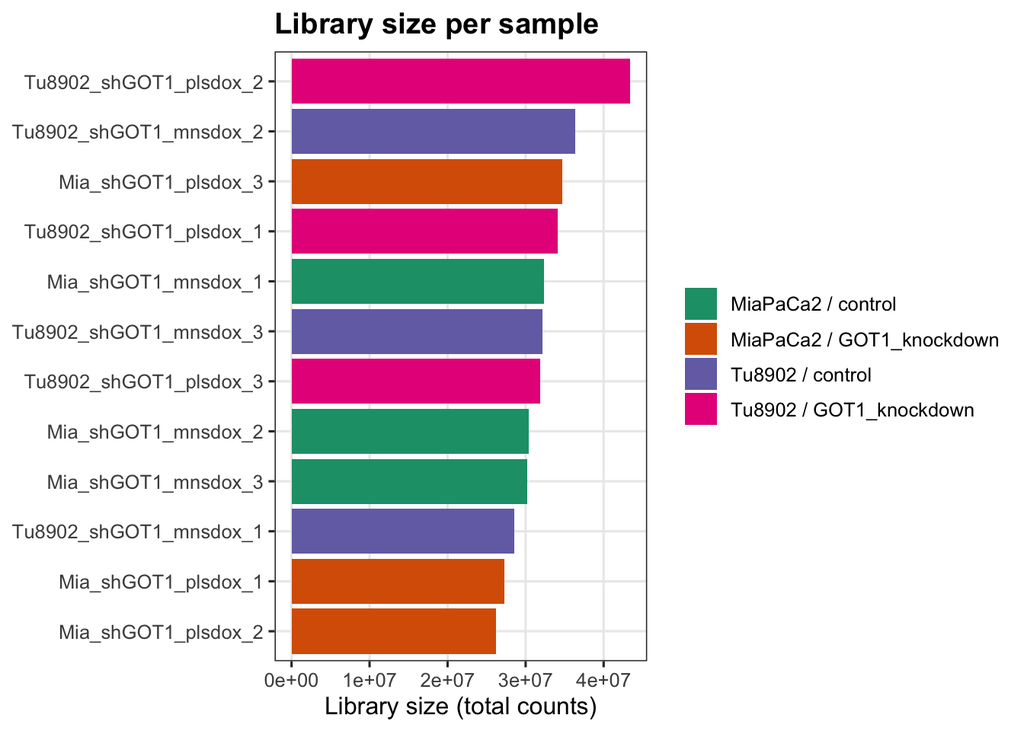

```r
grp <- meta$group
save_fig(plot_library_sizes(counts, grp),      file.path(FIG_DIR, "qc_library_sizes.png"))
save_fig(plot_count_distribution(counts, grp), file.path(FIG_DIR, "qc_count_distribution.png"),
         height = 6)
plot_library_sizes(counts, grp)
```

### PCA — colored by treatment, shaped by cell line

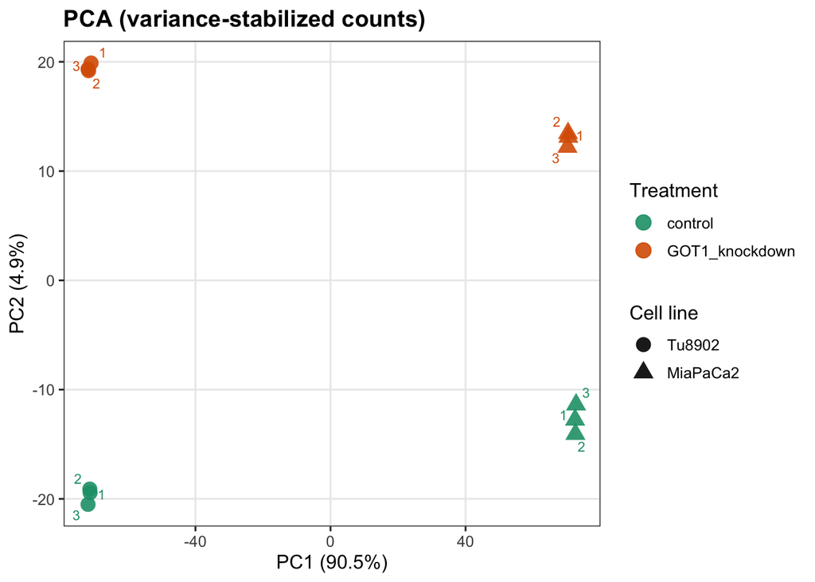

```r
vsd_mat <- SummarizedExperiment::assay(de$vsd)
pc <- prcomp(t(vsd_mat))
ve <- round(100 * pc$sdev^2 / sum(pc$sdev^2), 1)
pca_df <- data.frame(PC1 = pc$x[, 1], PC2 = pc$x[, 2], meta)

p_pca <- ggplot(pca_df, aes(PC1, PC2, color = treatment, shape = cell_line)) +
  geom_point(size = 4, alpha = 0.9) +
  ggrepel::geom_text_repel(aes(label = replicate), size = 3, show.legend = FALSE) +
  scale_color_manual(values = c(control = "#1b9e77", GOT1_knockdown = "#d95f02")) +
  labs(title = "PCA (variance-stabilized counts)",
       x = paste0("PC1 (", ve[1], "%)"), y = paste0("PC2 (", ve[2], "%)"),
       color = "Treatment", shape = "Cell line") +
  geo_theme()
save_fig(p_pca, file.path(FIG_DIR, "qc_pca.png"))
p_pca
```

### Sample-sample correlation heatmap

```r
plot_sample_correlation(vsd_mat, group = meta$treatment,
                        file = file.path(FIG_DIR, "qc_sample_correlation.png"))
plot_sample_correlation(vsd_mat, group = meta$treatment)
```

[output not shown]

## 6. Differential-expression figures

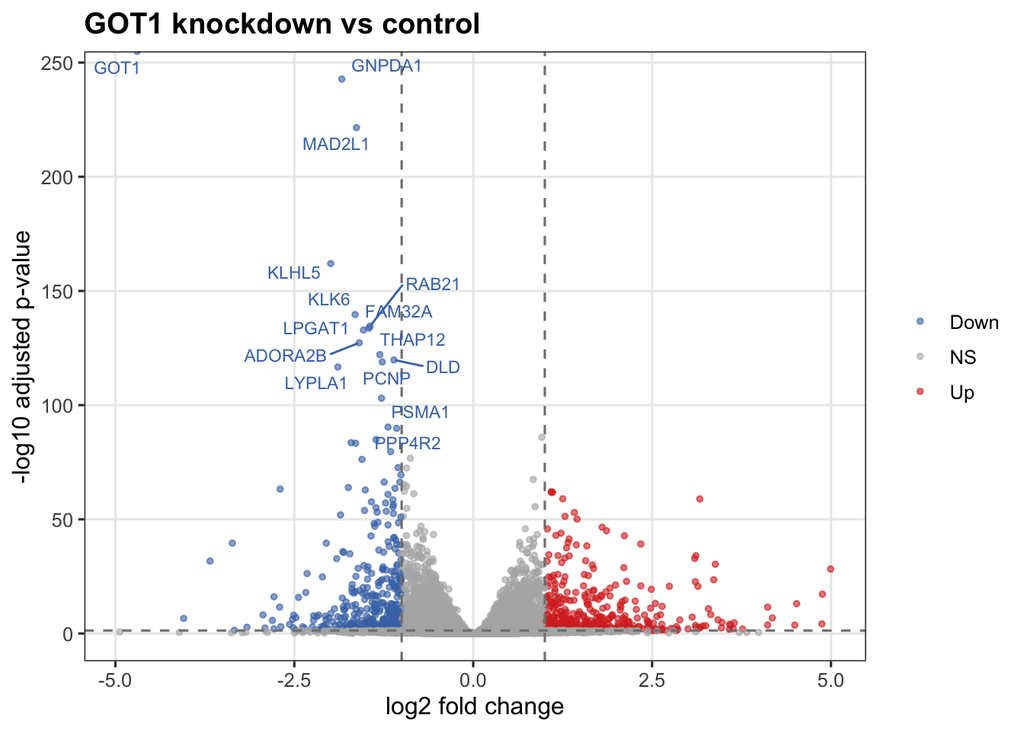

```r
save_fig(volcano_plot(de$res_df, title = "GOT1 knockdown vs control"),
         file.path(FIG_DIR, "volcano.png"))
volcano_plot(de$res_df, title = "GOT1 knockdown vs control")
```

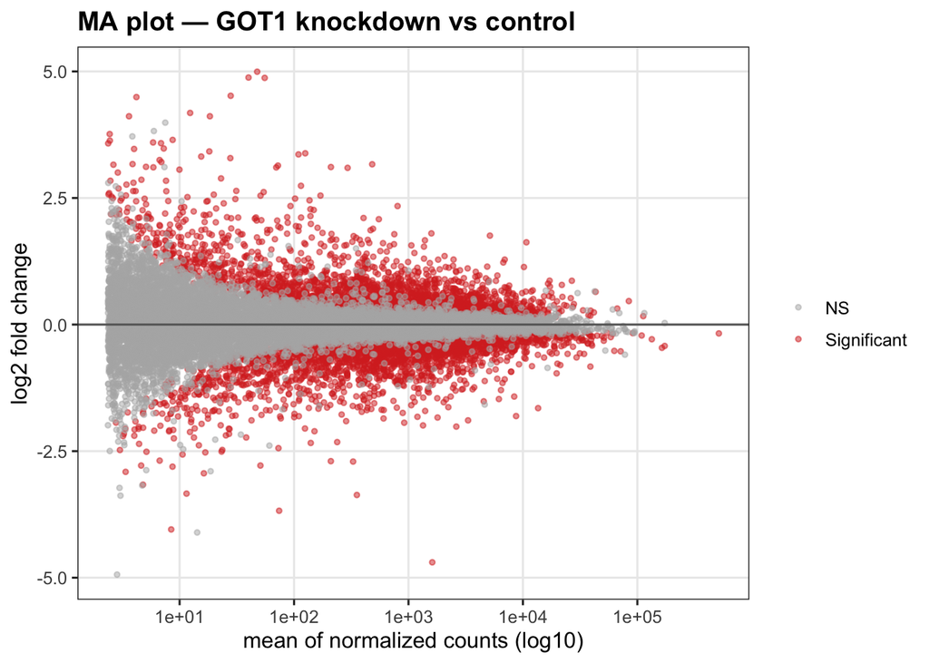

```r
save_fig(ma_plot(de$res_df, title = "MA plot — GOT1 knockdown vs control"),
         file.path(FIG_DIR, "ma_plot.png"))
ma_plot(de$res_df, title = "MA plot — GOT1 knockdown vs control")
```

```r
top_gene_heatmap(de$vsd, de$res_df, n = 30, group = meta$treatment,
                 file = file.path(FIG_DIR, "top_genes_heatmap.png"),
                 id_col = "gene_id", label_col = "symbol")
```

[output not shown]

```r
top_tbl <- head(de$res_df[order(de$res_df$padj),
                          c("symbol", "gene_id", "baseMean",
                            "log2FoldChange", "pvalue", "padj")], 25)
knitr::kable(top_tbl, digits = 3, caption = "Top 25 differentially expressed genes")
```

Top 25 differentially expressed genes

| symbol | gene_id | baseMean | log2FoldChange | pvalue | padj |
| --- | --- | --- | --- | --- | --- |
| GOT1 | ENSG00000120053.11 | 1614.100 | -4.696 | 0 | 0 |
| GNPDA1 | ENSG00000113552.15 | 1795.640 | -1.836 | 0 | 0 |
| MAD2L1 | ENSG00000164109.13 | 2229.577 | -1.632 | 0 | 0 |
| KLHL5 | ENSG00000109790.16 | 1340.220 | -1.992 | 0 | 0 |
| KLK6 | ENSG00000167755.14 | 13576.563 | -1.651 | 0 | 0 |
| RAB21 | ENSG00000080371.5 | 1346.634 | -1.442 | 0 | 0 |
| FAM32A | ENSG00000105058.11 | 1785.381 | -1.455 | 0 | 0 |
| LPGAT1 | ENSG00000123684.12 | 2031.223 | -1.535 | 0 | 0 |
| ADORA2B | ENSG00000170425.3 | 1058.101 | -1.593 | 0 | 0 |
| THAP12 | ENSG00000137492.7 | 2578.488 | -1.306 | 0 | 0 |
| DLD | ENSG00000091140.13 | 3080.604 | -1.108 | 0 | 0 |
| PCNP | ENSG00000081154.11 | 2986.465 | -1.272 | 0 | 0 |
| LYPLA1 | ENSG00000120992.17 | 3316.853 | -1.892 | 0 | 0 |
| PSMA1 | ENSG00000129084.17 | 2916.824 | -1.282 | 0 | 0 |
| PPP4R2 | ENSG00000163605.14 | 1627.094 | -1.190 | 0 | 0 |
| XPOT | ENSG00000184575.11 | 5968.521 | -1.070 | 0 | 0 |
| SLC6A6 | ENSG00000131389.17 | 4015.281 | 0.960 | 0 | 0 |
| SNX30 | ENSG00000148158.16 | 591.567 | -1.358 | 0 | 0 |
| KLK7 | ENSG00000169035.11 | 1398.671 | -1.706 | 0 | 0 |
| MREG | ENSG00000118242.15 | 437.651 | -1.644 | 0 | 0 |
| MTPN | ENSG00000105887.10 | 6632.990 | -1.154 | 0 | 0 |
| BTBD1 | ENSG00000064726.9 | 2325.026 | -0.879 | 0 | 0 |
| CSGALNACT2 | ENSG00000169826.7 | 502.010 | -1.554 | 0 | 0 |
| ANKRD27 | ENSG00000105186.15 | 1634.724 | -1.050 | 0 | 0 |
| ACLY | ENSG00000131473.16 | 7883.909 | -0.932 | 0 | 0 |

## 7. Functional enrichment (GO biological process)

Significant genes (`padj < 0.05`, `|log2FC| > 1`) are tested for GO-BP over-representation using the in-file **Entrez** IDs via clusterProfiler.

```r
sig <- subset(de$res_df, !is.na(padj) & padj < 0.05 &
                         abs(log2FoldChange) > 1 & !is.na(entrez))
cat("Significant genes for enrichment:", nrow(sig), "\n")
```

```
Significant genes for enrichment: 790
```

```r
ego <- tryCatch(
  clusterProfiler::enrichGO(
    gene = unique(as.character(sig$entrez)),
    OrgDb = "org.Hs.eg.db", keyType = "ENTREZID",
    ont = "BP", pvalueCutoff = 0.05, qvalueCutoff = 0.1, readable = TRUE),
  error = function(e) { warning(conditionMessage(e)); NULL })
```

```r
if (!is.null(ego) && nrow(as.data.frame(ego)) > 0) {
  write_results_table(as.data.frame(ego),
                      file.path(TAB_DIR, paste0(ACC, "_GO_BP_enrichment.csv")))
  save_fig(barplot(ego, showCategory = 15) + ggtitle("GO BP enrichment"),
           file.path(FIG_DIR, "go_bp_enrichment.png"), height = 7)
  knitr::kable(head(as.data.frame(ego)[, c("ID", "Description", "p.adjust", "Count")], 15),
               caption = "Top GO biological-process terms")
} else {
  cat("No significant GO-BP enrichment returned.\n")
}
```

Top GO biological-process terms

|  | ID | Description | p.adjust | Count |
| --- | --- | --- | --- | --- |
| GO:0002294 | GO:0002294 | CD4-positive, alpha-beta T cell differentiation involved in immune response | 0.0070261 | 13 |
| GO:0002287 | GO:0002287 | alpha-beta T cell activation involved in immune response | 0.0070261 | 13 |
| GO:0002293 | GO:0002293 | alpha-beta T cell differentiation involved in immune response | 0.0070261 | 13 |
| GO:0045785 | GO:0045785 | positive regulation of cell adhesion | 0.0077505 | 37 |
| GO:0043367 | GO:0043367 | CD4-positive, alpha-beta T cell differentiation | 0.0077505 | 14 |
| GO:0046632 | GO:0046632 | alpha-beta T cell differentiation | 0.0083881 | 16 |
| GO:0002292 | GO:0002292 | T cell differentiation involved in immune response | 0.0083881 | 13 |
| GO:0042093 | GO:0042093 | T-helper cell differentiation | 0.0096534 | 12 |
| GO:0030278 | GO:0030278 | regulation of ossification | 0.0108337 | 15 |
| GO:0032305 | GO:0032305 | positive regulation of icosanoid secretion | 0.0172488 | 6 |
| GO:0032303 | GO:0032303 | regulation of icosanoid secretion | 0.0281141 | 6 |
| GO:0098742 | GO:0098742 | cell-cell adhesion via plasma-membrane adhesion molecules | 0.0281141 | 23 |
| GO:0030217 | GO:0030217 | T cell differentiation | 0.0281141 | 25 |
| GO:0046598 | GO:0046598 | positive regulation of viral entry into host cell | 0.0281141 | 5 |
| GO:0075294 | GO:0075294 | positive regulation by symbiont of entry into host | 0.0281141 | 5 |

## 8. Interpretation

*Grounded in the rendered results (21,339 genes tested; 933 significant at `padj < 0.05` and `|log2FC| > 1`, adjusted for cell line).*

- **The perturbation worked — positive control confirmed.** GOT1 is the single most significant gene in the entire analysis (log2FC ≈ **−4.7**, ~26-fold down, `padj ≈ 0`), exactly as expected for an effective shRNA knockdown and consistent with the ~20–30× raw-count drop seen during triage.
- **A robust, cell-line-shared response.** Because the design adjusts for the (dominant) cell-line axis, the 933 differentially expressed genes represent a GOT1-dependent program common to both Tu8902 and MiaPaCa2 rather than a one-line artifact.
- **Down with GOT1:** alongside GOT1, the strongest losses include **DCLK1** (a pancreatic tumor progenitor/stemness marker), **KLF12**, and **INHBE** — consistent with disruption of a pro-tumorigenic metabolic program.
- **Up on knockdown:** several solute carriers / transporters (**METTL7A**, **SLC5A5/NIS**, **SLC9A4**) and the immune-modulatory **VTCN1 (B7-H4)** rise, suggesting transport and metabolic adaptation to the redox stress of losing GOT1’s aspartate–malate shuttle activity.
- **Pathway signal is real but diffuse.** GO biological-process over-representation returns 43 terms led by T-cell differentiation / immune response, cell adhesion, and eicosanoid secretion. Notably, generic GO-BP ORA does **not** by itself reconstruct the study’s ferroptosis/iron narrative — that signal lives in specific redox/iron genes, not broad GO-BP categories. Targeted gene-set analysis (ferroptosis, iron homeostasis, GSEA on the ranked list) would be the appropriate follow-up and is noted as a limitation, not overclaimed here.

## 9. Limitations

- **Control = uninduced (−Dox), not a non-targeting shRNA +Dox arm.** A doxycycline-intrinsic transcriptional effect cannot be fully separated from the GOT1-knockdown effect (suitability note A5).
- **RSEM expected counts were rounded** to satisfy DESeq2’s integer requirement; importing per-transcript estimates via `tximport` would propagate uncertainty more rigorously.
- **Additive model only** (`~ cell_line + treatment`): it estimates a *shared* knockdown effect and does not test whether the response differs between cell lines (that would need `~ cell_line * treatment`).
- **Two cell lines, n = 3 each** — adequate for DE but a limited sampling of PDAC heterogeneity; findings are about these models, not PDAC in general.
- **GO-BP over-representation is a blunt instrument here** — it does not recover the ferroptosis/iron theme; ranked-list GSEA against curated ferroptosis/iron gene sets would test that hypothesis directly.
- Annotation uses the submitter-provided gene/Entrez IDs; a small number of duplicated symbols/Ensembl IDs were de-duplicated (`make.unique`).